# Risk Factor Analysis

## Outcome Variable

**Outcome Variable:** whz

## Predictor Variables

**Intervention Variable:** enstunt

**Adjustment Set:**

- arm
- sex
- W_mage
- meducyrs
- feducyrs
- vagbrth
- single
- brthmon
- W_parity
- delta_W_mage
- delta_meducyrs
- delta_feducyrs
- delta_vagbrth
- delta_single
- delta_brthmon
- delta_W_parity

## Stratifying Variables

The analysis was stratified on these variable(s):

- agecat
- studyid
- country

## Data Summary

| agecat | studyid | country | enstunt | n_cell | n | outcome_variable |
| --- | --- | --- | --- | --- | --- | --- |
| Birth | ki0047075b-MAL-ED | BANGLADESH | 0 | 187 | 215 | whz |
| Birth | ki0047075b-MAL-ED | BANGLADESH | 1 | 28 | 215 | whz |
| Birth | ki0047075b-MAL-ED | BRAZIL | 0 | 56 | 62 | whz |
| Birth | ki0047075b-MAL-ED | BRAZIL | 1 | 6 | 62 | whz |
| Birth | ki0047075b-MAL-ED | INDIA | 0 | 37 | 45 | whz |
| Birth | ki0047075b-MAL-ED | INDIA | 1 | 8 | 45 | whz |
| Birth | ki0047075b-MAL-ED | NEPAL | 0 | 25 | 26 | whz |
| Birth | ki0047075b-MAL-ED | NEPAL | 1 | 1 | 26 | whz |
| Birth | ki0047075b-MAL-ED | PERU | 0 | 207 | 228 | whz |
| Birth | ki0047075b-MAL-ED | PERU | 1 | 21 | 228 | whz |
| Birth | ki0047075b-MAL-ED | SOUTH AFRICA | 0 | 112 | 120 | whz |
| Birth | ki0047075b-MAL-ED | SOUTH AFRICA | 1 | 8 | 120 | whz |
| Birth | ki0047075b-MAL-ED | TANZANIA, UNITED REPUBLIC OF | 0 | 102 | 115 | whz |
| Birth | ki0047075b-MAL-ED | TANZANIA, UNITED REPUBLIC OF | 1 | 13 | 115 | whz |
| Birth | ki1000108-CMC-V-BCS-2002 | INDIA | 0 | 74 | 86 | whz |
| Birth | ki1000108-CMC-V-BCS-2002 | INDIA | 1 | 12 | 86 | whz |
| Birth | ki1000108-IRC | INDIA | 0 | 318 | 343 | whz |
| Birth | ki1000108-IRC | INDIA | 1 | 25 | 343 | whz |
| Birth | ki1000109-EE | PAKISTAN | 0 | 137 | 177 | whz |
| Birth | ki1000109-EE | PAKISTAN | 1 | 40 | 177 | whz |
| Birth | ki1000109-ResPak | PAKISTAN | 0 | 28 | 38 | whz |
| Birth | ki1000109-ResPak | PAKISTAN | 1 | 10 | 38 | whz |
| Birth | ki1000304b-SAS-CompFeed | INDIA | 0 | 901 | 1103 | whz |
| Birth | ki1000304b-SAS-CompFeed | INDIA | 1 | 202 | 1103 | whz |
| Birth | ki1017093-NIH-Birth | BANGLADESH | 0 | 506 | 575 | whz |
| Birth | ki1017093-NIH-Birth | BANGLADESH | 1 | 69 | 575 | whz |
| Birth | ki1017093b-PROVIDE | BANGLADESH | 0 | 491 | 532 | whz |
| Birth | ki1017093b-PROVIDE | BANGLADESH | 1 | 41 | 532 | whz |
| Birth | ki1017093c-NIH-Crypto | BANGLADESH | 0 | 625 | 707 | whz |
| Birth | ki1017093c-NIH-Crypto | BANGLADESH | 1 | 82 | 707 | whz |

[output cut: 134 more lines]

The following strata were considered:

- agecat: 24 months, studyid: ki0047075b-MAL-ED, country: BANGLADESH
- agecat: 24 months, studyid: ki0047075b-MAL-ED, country: BRAZIL
- agecat: 24 months, studyid: ki0047075b-MAL-ED, country: INDIA
- agecat: 24 months, studyid: ki0047075b-MAL-ED, country: NEPAL
- agecat: 24 months, studyid: ki0047075b-MAL-ED, country: PERU
- agecat: 24 months, studyid: ki0047075b-MAL-ED, country: SOUTH AFRICA
- agecat: 24 months, studyid: ki0047075b-MAL-ED, country: TANZANIA, UNITED REPUBLIC OF
- agecat: 24 months, studyid: ki1000108-CMC-V-BCS-2002, country: INDIA
- agecat: 24 months, studyid: ki1000108-IRC, country: INDIA
- agecat: 24 months, studyid: ki1000109-EE, country: PAKISTAN
- agecat: 24 months, studyid: ki1017093-NIH-Birth, country: BANGLADESH
- agecat: 24 months, studyid: ki1017093b-PROVIDE, country: BANGLADESH
- agecat: 24 months, studyid: ki1017093c-NIH-Crypto, country: BANGLADESH
- agecat: 24 months, studyid: ki1066203-TanzaniaChild2, country: TANZANIA, UNITED REPUBLIC OF
- agecat: 24 months, studyid: ki1101329-Keneba, country: GAMBIA
- agecat: 24 months, studyid: ki1113344-GMS-Nepal, country: NEPAL
- agecat: 24 months, studyid: ki1114097-CMIN, country: BANGLADESH
- agecat: 24 months, studyid: ki1114097-CONTENT, country: PERU
- agecat: 24 months, studyid: ki1119695-PROBIT, country: BELARUS
- agecat: 24 months, studyid: ki1126311-ZVITAMBO, country: ZIMBABWE
- agecat: 24 months, studyid: ki1135781-COHORTS, country: GUATEMALA
- agecat: 24 months, studyid: ki1135781-COHORTS, country: INDIA
- agecat: 24 months, studyid: ki1135781-COHORTS, country: PHILIPPINES
- agecat: 24 months, studyid: ki1148112-LCNI-5, country: MALAWI
- agecat: 24 months, studyid: kiGH5241-JiVitA-3, country: BANGLADESH
- agecat: 24 months, studyid: kiGH5241-JiVitA-4, country: BANGLADESH
- agecat: 6 months, studyid: ki0047075b-MAL-ED, country: BANGLADESH
- agecat: 6 months, studyid: ki0047075b-MAL-ED, country: BRAZIL
- agecat: 6 months, studyid: ki0047075b-MAL-ED, country: INDIA
- agecat: 6 months, studyid: ki0047075b-MAL-ED, country: NEPAL
- agecat: 6 months, studyid: ki0047075b-MAL-ED, country: PERU
- agecat: 6 months, studyid: ki0047075b-MAL-ED, country: SOUTH AFRICA
- agecat: 6 months, studyid: ki0047075b-MAL-ED, country: TANZANIA, UNITED REPUBLIC OF
- agecat: 6 months, studyid: ki1000108-CMC-V-BCS-2002, country: INDIA
- agecat: 6 months, studyid: ki1000108-IRC, country: INDIA
- agecat: 6 months, studyid: ki1000109-EE, country: PAKISTAN
- agecat: 6 months, studyid: ki1000109-ResPak, country: PAKISTAN
- agecat: 6 months, studyid: ki1000304b-SAS-CompFeed, country: INDIA
- agecat: 6 months, studyid: ki1000304b-SAS-FoodSuppl, country: INDIA
- agecat: 6 months, studyid: ki1017093-NIH-Birth, country: BANGLADESH
- agecat: 6 months, studyid: ki1017093b-PROVIDE, country: BANGLADESH
- agecat: 6 months, studyid: ki1017093c-NIH-Crypto, country: BANGLADESH
- agecat: 6 months, studyid: ki1066203-TanzaniaChild2, country: TANZANIA, UNITED REPUBLIC OF
- agecat: 6 months, studyid: ki1101329-Keneba, country: GAMBIA
- agecat: 6 months, studyid: ki1112895-Guatemala BSC, country: GUATEMALA
- agecat: 6 months, studyid: ki1113344-GMS-Nepal, country: NEPAL
- agecat: 6 months, studyid: ki1114097-CMIN, country: BANGLADESH
- agecat: 6 months, studyid: ki1114097-CONTENT, country: PERU
- agecat: 6 months, studyid: ki1119695-PROBIT, country: BELARUS
- agecat: 6 months, studyid: ki1126311-ZVITAMBO, country: ZIMBABWE
- agecat: 6 months, studyid: ki1135781-COHORTS, country: GUATEMALA
- agecat: 6 months, studyid: ki1135781-COHORTS, country: INDIA
- agecat: 6 months, studyid: ki1135781-COHORTS, country: PHILIPPINES
- agecat: 6 months, studyid: ki1148112-LCNI-5, country: MALAWI
- agecat: 6 months, studyid: kiGH5241-JiVitA-3, country: BANGLADESH
- agecat: 6 months, studyid: kiGH5241-JiVitA-4, country: BANGLADESH
- agecat: Birth, studyid: ki0047075b-MAL-ED, country: BANGLADESH
- agecat: Birth, studyid: ki0047075b-MAL-ED, country: BRAZIL
- agecat: Birth, studyid: ki0047075b-MAL-ED, country: INDIA
- agecat: Birth, studyid: ki0047075b-MAL-ED, country: NEPAL
- agecat: Birth, studyid: ki0047075b-MAL-ED, country: PERU
- agecat: Birth, studyid: ki0047075b-MAL-ED, country: SOUTH AFRICA
- agecat: Birth, studyid: ki0047075b-MAL-ED, country: TANZANIA, UNITED REPUBLIC OF
- agecat: Birth, studyid: ki1000108-CMC-V-BCS-2002, country: INDIA
- agecat: Birth, studyid: ki1000108-IRC, country: INDIA
- agecat: Birth, studyid: ki1000109-EE, country: PAKISTAN
- agecat: Birth, studyid: ki1000109-ResPak, country: PAKISTAN
- agecat: Birth, studyid: ki1000304b-SAS-CompFeed, country: INDIA
- agecat: Birth, studyid: ki1017093-NIH-Birth, country: BANGLADESH
- agecat: Birth, studyid: ki1017093b-PROVIDE, country: BANGLADESH
- agecat: Birth, studyid: ki1017093c-NIH-Crypto, country: BANGLADESH
- agecat: Birth, studyid: ki1101329-Keneba, country: GAMBIA
- agecat: Birth, studyid: ki1113344-GMS-Nepal, country: NEPAL
- agecat: Birth, studyid: ki1114097-CMIN, country: BANGLADESH
- agecat: Birth, studyid: ki1114097-CONTENT, country: PERU
- agecat: Birth, studyid: ki1119695-PROBIT, country: BELARUS
- agecat: Birth, studyid: ki1126311-ZVITAMBO, country: ZIMBABWE
- agecat: Birth, studyid: ki1135781-COHORTS, country: GUATEMALA
- agecat: Birth, studyid: ki1135781-COHORTS, country: INDIA
- agecat: Birth, studyid: ki1135781-COHORTS, country: PHILIPPINES
- agecat: Birth, studyid: kiGH5241-JiVitA-3, country: BANGLADESH
- agecat: Birth, studyid: kiGH5241-JiVitA-4, country: BANGLADESH

### Dropped Strata

Some strata were dropped due to rare outcomes:

- agecat: Birth, studyid: ki0047075b-MAL-ED, country: NEPAL
- agecat: Birth, studyid: ki1114097-CMIN, country: BANGLADESH
- agecat: Birth, studyid: ki1114097-CONTENT, country: PERU
- agecat: 24 months, studyid: ki1066203-TanzaniaChild2, country: TANZANIA, UNITED REPUBLIC OF

## Methods Detail

We’re interested in the causal parameters $E[Y_a]$ for all values of $a \in \mathcal{A}$. These parameters represent the mean outcome if, possibly contrary to fact, we intervened to set all units to have $A=a$. Under the randomization and positivity assumptions, these are identified by the statistical parameters $\psi_a=E_W[E_{Y|A,W}(Y|A=a,W)]$. In addition, we’re interested in the mean of $Y$, $E[Y]$ under no intervention (the observed mean). We will estimate these parameters by using SuperLearner to fit the relevant likelihood factors – $E_{Y|A,W}(Y|A=a,W)$ and $p(A=a|W)$, and then updating our likelihood fit using a joint TMLE.

For unadjusted analyses ($W=\{\}$), initial likelihoods were estimated using Lrnr_glm to estimate the simple $E(Y|A)$ and Lrnr_mean to estimate $p(A)$. For adjusted analyses, a small library containing Lrnr_glmnet, Lrnr_xgboost, and Lrnr_mean was used.

# Results Detail

## Results Plots

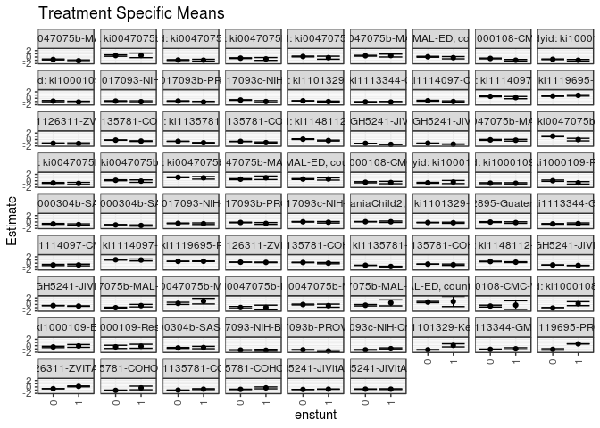

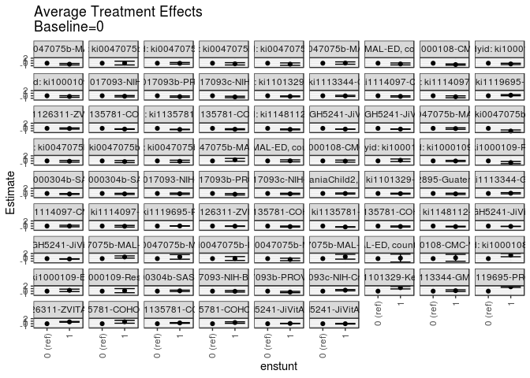

[figure not shown]

## Results Table

### Parameter: TSM

| agecat | studyid | country | intervention_level | baseline_level | estimate | ci_lower | ci_upper |
| --- | --- | --- | --- | --- | --- | --- | --- |
| Birth | ki0047075b-MAL-ED | BANGLADESH | 0 | NA | -0.9994736 | -1.1513534 | -0.8475937 |
| Birth | ki0047075b-MAL-ED | BANGLADESH | 1 | NA | -0.3677204 | -0.7571082 | 0.0216674 |
| Birth | ki0047075b-MAL-ED | BRAZIL | 0 | NA | 0.3380357 | 0.0083857 | 0.6676857 |
| Birth | ki0047075b-MAL-ED | BRAZIL | 1 | NA | 1.0083333 | 0.1448999 | 1.8717667 |
| Birth | ki0047075b-MAL-ED | INDIA | 0 | NA | -0.9356757 | -1.2327587 | -0.6385926 |
| Birth | ki0047075b-MAL-ED | INDIA | 1 | NA | -0.9175000 | -1.6199423 | -0.2150577 |
| Birth | ki0047075b-MAL-ED | PERU | 0 | NA | -0.0243560 | -0.1524948 | 0.1037828 |
| Birth | ki0047075b-MAL-ED | PERU | 1 | NA | -0.3733913 | -0.8449607 | 0.0981781 |
| Birth | ki0047075b-MAL-ED | SOUTH AFRICA | 0 | NA | -0.2412500 | -0.4566344 | -0.0258656 |
| Birth | ki0047075b-MAL-ED | SOUTH AFRICA | 1 | NA | 0.4887500 | -0.4348184 | 1.4123184 |
| Birth | ki0047075b-MAL-ED | TANZANIA, UNITED REPUBLIC OF | 0 | NA | 0.7332018 | 0.5404640 | 0.9259395 |
| Birth | ki0047075b-MAL-ED | TANZANIA, UNITED REPUBLIC OF | 1 | NA | 0.9055909 | -0.6543145 | 2.4654963 |
| Birth | ki1000108-CMC-V-BCS-2002 | INDIA | 0 | NA | -0.5002245 | -0.7869685 | -0.2134805 |
| Birth | ki1000108-CMC-V-BCS-2002 | INDIA | 1 | NA | -0.1967358 | -1.5287831 | 1.1353115 |
| Birth | ki1000108-IRC | INDIA | 0 | NA | -1.1111703 | -1.3022982 | -0.9200424 |
| Birth | ki1000108-IRC | INDIA | 1 | NA | 0.2435522 | -0.3608818 | 0.8479863 |
| Birth | ki1000109-EE | PAKISTAN | 0 | NA | -0.3935254 | -0.6014209 | -0.1856299 |
| Birth | ki1000109-EE | PAKISTAN | 1 | NA | -0.0803787 | -0.5108466 | 0.3500892 |
| Birth | ki1000109-ResPak | PAKISTAN | 0 | NA | -0.3614575 | -0.8534941 | 0.1305792 |
| Birth | ki1000109-ResPak | PAKISTAN | 1 | NA | -0.1727339 | -0.7904522 | 0.4449844 |
| Birth | ki1000304b-SAS-CompFeed | INDIA | 0 | NA | -0.6916348 | -0.8421737 | -0.5410959 |
| Birth | ki1000304b-SAS-CompFeed | INDIA | 1 | NA | -0.5654183 | -0.9273312 | -0.2035054 |
| Birth | ki1017093-NIH-Birth | BANGLADESH | 0 | NA | -1.3472249 | -1.4472168 | -1.2472330 |
| Birth | ki1017093-NIH-Birth | BANGLADESH | 1 | NA | -1.4108565 | -1.7019482 | -1.1197647 |
| Birth | ki1017093b-PROVIDE | BANGLADESH | 0 | NA | -1.2753304 | -1.3560719 | -1.1945890 |
| Birth | ki1017093b-PROVIDE | BANGLADESH | 1 | NA | -1.6269684 | -1.8745730 | -1.3793637 |
| Birth | ki1017093c-NIH-Crypto | BANGLADESH | 0 | NA | -1.2842341 | -1.3737021 | -1.1947661 |
| Birth | ki1017093c-NIH-Crypto | BANGLADESH | 1 | NA | -0.9123119 | -1.1423278 | -0.6822960 |
| Birth | ki1101329-Keneba | GAMBIA | 0 | NA | -1.2661717 | -1.3281500 | -1.2041933 |
| Birth | ki1101329-Keneba | GAMBIA | 1 | NA | 0.1060909 | -0.3806416 | 0.5928235 |

[output cut: 126 more lines]

### Parameter: E(Y)

| agecat | studyid | country | intervention_level | baseline_level | estimate | ci_lower | ci_upper |
| --- | --- | --- | --- | --- | --- | --- | --- |
| Birth | ki0047075b-MAL-ED | BANGLADESH | NA | NA | -0.9418605 | -1.0869834 | -0.7967375 |
| Birth | ki0047075b-MAL-ED | BRAZIL | NA | NA | 0.4029032 | 0.0896793 | 0.7161272 |
| Birth | ki0047075b-MAL-ED | INDIA | NA | NA | -0.9324444 | -1.2067907 | -0.6580982 |
| Birth | ki0047075b-MAL-ED | PERU | NA | NA | -0.0520175 | -0.1725298 | 0.0684947 |
| Birth | ki0047075b-MAL-ED | SOUTH AFRICA | NA | NA | -0.1925833 | -0.4053570 | 0.0201904 |
| Birth | ki0047075b-MAL-ED | TANZANIA, UNITED REPUBLIC OF | NA | NA | 0.7624348 | 0.5710709 | 0.9537986 |
| Birth | ki1000108-CMC-V-BCS-2002 | INDIA | NA | NA | -0.4648256 | -0.7643210 | -0.1653302 |
| Birth | ki1000108-IRC | INDIA | NA | NA | -1.0105831 | -1.1973019 | -0.8238643 |
| Birth | ki1000109-EE | PAKISTAN | NA | NA | -0.3333051 | -0.5209779 | -0.1456323 |
| Birth | ki1000109-ResPak | PAKISTAN | NA | NA | -0.3663158 | -0.7677415 | 0.0351099 |
| Birth | ki1000304b-SAS-CompFeed | INDIA | NA | NA | -0.6700453 | -0.8474950 | -0.4925957 |
| Birth | ki1017093-NIH-Birth | BANGLADESH | NA | NA | -1.3499217 | -1.4444634 | -1.2553801 |
| Birth | ki1017093b-PROVIDE | BANGLADESH | NA | NA | -1.2984586 | -1.3752758 | -1.2216415 |
| Birth | ki1017093c-NIH-Crypto | BANGLADESH | NA | NA | -1.2441513 | -1.3281130 | -1.1601897 |
| Birth | ki1101329-Keneba | GAMBIA | NA | NA | -1.2349454 | -1.2972413 | -1.1726496 |
| Birth | ki1113344-GMS-Nepal | NEPAL | NA | NA | -1.1164431 | -1.2040134 | -1.0288728 |
| Birth | ki1119695-PROBIT | BELARUS | NA | NA | -1.1448633 | -1.3544229 | -0.9353037 |
| Birth | ki1126311-ZVITAMBO | ZIMBABWE | NA | NA | -0.5154897 | -0.5413479 | -0.4896314 |
| Birth | ki1135781-COHORTS | GUATEMALA | NA | NA | -1.0621429 | -1.1631387 | -0.9611471 |
| Birth | ki1135781-COHORTS | INDIA | NA | NA | -0.9847457 | -1.0145305 | -0.9549609 |
| Birth | ki1135781-COHORTS | PHILIPPINES | NA | NA | -0.7427251 | -0.7890855 | -0.6963647 |
| Birth | kiGH5241-JiVitA-3 | BANGLADESH | NA | NA | -0.7778272 | -0.7968313 | -0.7588232 |
| Birth | kiGH5241-JiVitA-4 | BANGLADESH | NA | NA | -0.6886269 | -0.7410452 | -0.6362086 |
| 6 months | ki0047075b-MAL-ED | BANGLADESH | NA | NA | -0.1376763 | -0.2664642 | -0.0088885 |
| 6 months | ki0047075b-MAL-ED | BRAZIL | NA | NA | 0.9720774 | 0.8078144 | 1.1363403 |
| 6 months | ki0047075b-MAL-ED | INDIA | NA | NA | -0.7079979 | -0.8344175 | -0.5815783 |
| 6 months | ki0047075b-MAL-ED | NEPAL | NA | NA | 0.1104308 | -0.0208643 | 0.2417259 |
| 6 months | ki0047075b-MAL-ED | PERU | NA | NA | 1.0528816 | 0.9313005 | 1.1744626 |
| 6 months | ki0047075b-MAL-ED | SOUTH AFRICA | NA | NA | 0.5421785 | 0.3900443 | 0.6943126 |
| 6 months | ki0047075b-MAL-ED | TANZANIA, UNITED REPUBLIC OF | NA | NA | 0.5362213 | 0.4049390 | 0.6675036 |
| 6 months | ki1000108-CMC-V-BCS-2002 | INDIA | NA | NA | -0.5026766 | -0.6536848 | -0.3516685 |
| 6 months | ki1000108-IRC | INDIA | NA | NA | -0.5989297 | -0.7344491 | -0.4634104 |
| 6 months | ki1000109-EE | PAKISTAN | NA | NA | -0.7747022 | -0.8887874 | -0.6606170 |
| 6 months | ki1000109-ResPak | PAKISTAN | NA | NA | -0.1641841 | -0.3464247 | 0.0180565 |
| 6 months | ki1000304b-SAS-CompFeed | INDIA | NA | NA | -0.6657084 | -0.8024377 | -0.5289791 |
| 6 months | ki1000304b-SAS-FoodSuppl | INDIA | NA | NA | -1.0121579 | -1.1280429 | -0.8962729 |
| 6 months | ki1017093-NIH-Birth | BANGLADESH | NA | NA | -0.4474038 | -0.5378167 | -0.3569909 |
| 6 months | ki1017093b-PROVIDE | BANGLADESH | NA | NA | -0.1990907 | -0.2817968 | -0.1163845 |
| 6 months | ki1017093c-NIH-Crypto | BANGLADESH | NA | NA | 0.0297622 | -0.0491685 | 0.1086930 |
| 6 months | ki1066203-TanzaniaChild2 | TANZANIA, UNITED REPUBLIC OF | NA | NA | 0.0809332 | 0.0282644 | 0.1336020 |
| 6 months | ki1101329-Keneba | GAMBIA | NA | NA | -0.1846038 | -0.2354782 | -0.1337293 |
| 6 months | ki1112895-Guatemala BSC | GUATEMALA | NA | NA | -0.0840134 | -0.1945572 | 0.0265305 |
| 6 months | ki1113344-GMS-Nepal | NEPAL | NA | NA | -0.6038416 | -0.6899448 | -0.5177384 |
| 6 months | ki1114097-CMIN | BANGLADESH | NA | NA | -0.5780453 | -0.7226627 | -0.4334279 |
| 6 months | ki1114097-CONTENT | PERU | NA | NA | 1.0684318 | 0.9515274 | 1.1853362 |
| 6 months | ki1119695-PROBIT | BELARUS | NA | NA | 0.5792439 | 0.5193388 | 0.6391490 |
| 6 months | ki1126311-ZVITAMBO | ZIMBABWE | NA | NA | 0.3105514 | 0.2848767 | 0.3362262 |
| 6 months | ki1135781-COHORTS | GUATEMALA | NA | NA | 0.1940810 | 0.1226351 | 0.2655269 |
| 6 months | ki1135781-COHORTS | INDIA | NA | NA | -0.6908803 | -0.7184601 | -0.6633005 |
| 6 months | ki1135781-COHORTS | PHILIPPINES | NA | NA | -0.2938433 | -0.3352064 | -0.2524802 |
| 6 months | ki1148112-LCNI-5 | MALAWI | NA | NA | 0.4499404 | 0.3788501 | 0.5210308 |
| 6 months | kiGH5241-JiVitA-3 | BANGLADESH | NA | NA | -0.5935161 | -0.6130518 | -0.5739805 |
| 6 months | kiGH5241-JiVitA-4 | BANGLADESH | NA | NA | -0.3898055 | -0.4270507 | -0.3525603 |
| 24 months | ki0047075b-MAL-ED | BANGLADESH | NA | NA | -0.8192925 | -0.9412667 | -0.6973182 |
| 24 months | ki0047075b-MAL-ED | BRAZIL | NA | NA | 0.4626233 | 0.2567495 | 0.6684971 |
| 24 months | ki0047075b-MAL-ED | INDIA | NA | NA | -0.9516520 | -1.0670654 | -0.8362385 |
| 24 months | ki0047075b-MAL-ED | NEPAL | NA | NA | -0.3749123 | -0.4886073 | -0.2612173 |
| 24 months | ki0047075b-MAL-ED | PERU | NA | NA | 0.1111982 | -0.0118399 | 0.2342362 |
| 24 months | ki0047075b-MAL-ED | SOUTH AFRICA | NA | NA | 0.4090301 | 0.2879441 | 0.5301161 |
| 24 months | ki0047075b-MAL-ED | TANZANIA, UNITED REPUBLIC OF | NA | NA | 0.0547975 | -0.0703378 | 0.1799328 |
| 24 months | ki1000108-CMC-V-BCS-2002 | INDIA | NA | NA | -0.5571505 | -0.6585247 | -0.4557763 |
| 24 months | ki1000108-IRC | INDIA | NA | NA | -0.7458150 | -0.8368180 | -0.6548120 |
| 24 months | ki1000109-EE | PAKISTAN | NA | NA | -1.0120238 | -1.1588493 | -0.8651984 |
| 24 months | ki1017093-NIH-Birth | BANGLADESH | NA | NA | -0.9115790 | -1.0095022 | -0.8136559 |
| 24 months | ki1017093b-PROVIDE | BANGLADESH | NA | NA | -0.8928670 | -0.9755153 | -0.8102187 |
| 24 months | ki1017093c-NIH-Crypto | BANGLADESH | NA | NA | -0.6103502 | -0.7050157 | -0.5156847 |
| 24 months | ki1101329-Keneba | GAMBIA | NA | NA | -0.8099290 | -0.8570608 | -0.7627972 |
| 24 months | ki1113344-GMS-Nepal | NEPAL | NA | NA | -1.1363107 | -1.2252817 | -1.0473398 |
| 24 months | ki1114097-CMIN | BANGLADESH | NA | NA | -0.8535391 | -0.9644236 | -0.7426546 |
| 24 months | ki1114097-CONTENT | PERU | NA | NA | 0.5668293 | 0.4302437 | 0.7034148 |
| 24 months | ki1119695-PROBIT | BELARUS | NA | NA | 0.6874295 | 0.5756922 | 0.7991668 |
| 24 months | ki1126311-ZVITAMBO | ZIMBABWE | NA | NA | -1.1825404 | -1.2814625 | -1.0836183 |
| 24 months | ki1135781-COHORTS | GUATEMALA | NA | NA | -0.2815804 | -0.3354498 | -0.2277110 |
| 24 months | ki1135781-COHORTS | INDIA | NA | NA | -0.6073238 | -0.6354743 | -0.5791732 |
| 24 months | ki1135781-COHORTS | PHILIPPINES | NA | NA | -0.6099592 | -0.6467541 | -0.5731643 |
| 24 months | ki1148112-LCNI-5 | MALAWI | NA | NA | -0.0477709 | -0.1296526 | 0.0341109 |
| 24 months | kiGH5241-JiVitA-3 | BANGLADESH | NA | NA | -1.2978031 | -1.3210763 | -1.2745298 |
| 24 months | kiGH5241-JiVitA-4 | BANGLADESH | NA | NA | -1.2231088 | -1.2549632 | -1.1912543 |

### Parameter: ATE

| agecat | studyid | country | intervention_level | baseline_level | estimate | ci_lower | ci_upper |
| --- | --- | --- | --- | --- | --- | --- | --- |
| Birth | ki0047075b-MAL-ED | BANGLADESH | 0 | 0 | 0.0000000 | 0.0000000 | 0.0000000 |
| Birth | ki0047075b-MAL-ED | BANGLADESH | 1 | 0 | 0.6317531 | 0.2127945 | 1.0507118 |
| Birth | ki0047075b-MAL-ED | BRAZIL | 0 | 0 | 0.0000000 | 0.0000000 | 0.0000000 |
| Birth | ki0047075b-MAL-ED | BRAZIL | 1 | 0 | 0.6702976 | -0.2539244 | 1.5945196 |
| Birth | ki0047075b-MAL-ED | INDIA | 0 | 0 | 0.0000000 | 0.0000000 | 0.0000000 |
| Birth | ki0047075b-MAL-ED | INDIA | 1 | 0 | 0.0181757 | -0.7445061 | 0.7808575 |
| Birth | ki0047075b-MAL-ED | PERU | 0 | 0 | 0.0000000 | 0.0000000 | 0.0000000 |
| Birth | ki0047075b-MAL-ED | PERU | 1 | 0 | -0.3490353 | -0.8379131 | 0.1398425 |
| Birth | ki0047075b-MAL-ED | SOUTH AFRICA | 0 | 0 | 0.0000000 | 0.0000000 | 0.0000000 |
| Birth | ki0047075b-MAL-ED | SOUTH AFRICA | 1 | 0 | 0.7300000 | -0.2183507 | 1.6783507 |
| Birth | ki0047075b-MAL-ED | TANZANIA, UNITED REPUBLIC OF | 0 | 0 | 0.0000000 | 0.0000000 | 0.0000000 |
| Birth | ki0047075b-MAL-ED | TANZANIA, UNITED REPUBLIC OF | 1 | 0 | 0.1723891 | -1.4018620 | 1.7466402 |
| Birth | ki1000108-CMC-V-BCS-2002 | INDIA | 0 | 0 | 0.0000000 | 0.0000000 | 0.0000000 |
| Birth | ki1000108-CMC-V-BCS-2002 | INDIA | 1 | 0 | 0.3034887 | -1.0631405 | 1.6701179 |
| Birth | ki1000108-IRC | INDIA | 0 | 0 | 0.0000000 | 0.0000000 | 0.0000000 |
| Birth | ki1000108-IRC | INDIA | 1 | 0 | 1.3547225 | 0.7206858 | 1.9887592 |
| Birth | ki1000109-EE | PAKISTAN | 0 | 0 | 0.0000000 | 0.0000000 | 0.0000000 |
| Birth | ki1000109-EE | PAKISTAN | 1 | 0 | 0.3131467 | -0.1666549 | 0.7929483 |
| Birth | ki1000109-ResPak | PAKISTAN | 0 | 0 | 0.0000000 | 0.0000000 | 0.0000000 |
| Birth | ki1000109-ResPak | PAKISTAN | 1 | 0 | 0.1887235 | -0.6224225 | 0.9998696 |
| Birth | ki1000304b-SAS-CompFeed | INDIA | 0 | 0 | 0.0000000 | 0.0000000 | 0.0000000 |
| Birth | ki1000304b-SAS-CompFeed | INDIA | 1 | 0 | 0.1262165 | -0.1446809 | 0.3971139 |
| Birth | ki1017093-NIH-Birth | BANGLADESH | 0 | 0 | 0.0000000 | 0.0000000 | 0.0000000 |
| Birth | ki1017093-NIH-Birth | BANGLADESH | 1 | 0 | -0.0636316 | -0.3716821 | 0.2444189 |
| Birth | ki1017093b-PROVIDE | BANGLADESH | 0 | 0 | 0.0000000 | 0.0000000 | 0.0000000 |
| Birth | ki1017093b-PROVIDE | BANGLADESH | 1 | 0 | -0.3516379 | -0.6122601 | -0.0910158 |
| Birth | ki1017093c-NIH-Crypto | BANGLADESH | 0 | 0 | 0.0000000 | 0.0000000 | 0.0000000 |
| Birth | ki1017093c-NIH-Crypto | BANGLADESH | 1 | 0 | 0.3719221 | 0.1255071 | 0.6183372 |
| Birth | ki1101329-Keneba | GAMBIA | 0 | 0 | 0.0000000 | 0.0000000 | 0.0000000 |
| Birth | ki1101329-Keneba | GAMBIA | 1 | 0 | 1.3722626 | 0.8808007 | 1.8637245 |

[output cut: 126 more lines]

### Parameter: PAR

| agecat | studyid | country | intervention_level | baseline_level | estimate | ci_lower | ci_upper |
| --- | --- | --- | --- | --- | --- | --- | --- |
| Birth | ki0047075b-MAL-ED | BANGLADESH | 0 | NA | 0.0576131 | -0.0069150 | 0.1221412 |
| Birth | ki0047075b-MAL-ED | BRAZIL | 0 | NA | 0.0648675 | -0.0374695 | 0.1672045 |
| Birth | ki0047075b-MAL-ED | INDIA | 0 | NA | 0.0032312 | -0.1323722 | 0.1388347 |
| Birth | ki0047075b-MAL-ED | PERU | 0 | NA | -0.0276615 | -0.0722307 | 0.0169076 |
| Birth | ki0047075b-MAL-ED | SOUTH AFRICA | 0 | NA | 0.0486667 | -0.0225203 | 0.1198536 |
| Birth | ki0047075b-MAL-ED | TANZANIA, UNITED REPUBLIC OF | 0 | NA | 0.0292330 | -0.0781873 | 0.1366533 |
| Birth | ki1000108-CMC-V-BCS-2002 | INDIA | 0 | NA | 0.0353989 | -0.1431270 | 0.2139248 |
| Birth | ki1000108-IRC | INDIA | 0 | NA | 0.1005872 | 0.0399756 | 0.1611987 |
| Birth | ki1000109-EE | PAKISTAN | 0 | NA | 0.0602203 | -0.0487884 | 0.1692291 |
| Birth | ki1000109-ResPak | PAKISTAN | 0 | NA | -0.0048583 | -0.2973684 | 0.2876518 |
| Birth | ki1000304b-SAS-CompFeed | INDIA | 0 | NA | 0.0215895 | -0.0290866 | 0.0722655 |
| Birth | ki1017093-NIH-Birth | BANGLADESH | 0 | NA | -0.0026969 | -0.0394913 | 0.0340976 |
| Birth | ki1017093b-PROVIDE | BANGLADESH | 0 | NA | -0.0231282 | -0.0432851 | -0.0029713 |
| Birth | ki1017093c-NIH-Crypto | BANGLADESH | 0 | NA | 0.0400827 | 0.0098977 | 0.0702678 |
| Birth | ki1101329-Keneba | GAMBIA | 0 | NA | 0.0312262 | 0.0147804 | 0.0476720 |
| Birth | ki1113344-GMS-Nepal | NEPAL | 0 | NA | 0.0297225 | -0.0035939 | 0.0630389 |
| Birth | ki1119695-PROBIT | BELARUS | 0 | NA | 0.0032626 | -0.0017989 | 0.0083242 |
| Birth | ki1126311-ZVITAMBO | ZIMBABWE | 0 | NA | 0.0390396 | 0.0313074 | 0.0467718 |
| Birth | ki1135781-COHORTS | GUATEMALA | 0 | NA | 0.0247236 | 0.0043581 | 0.0450892 |
| Birth | ki1135781-COHORTS | INDIA | 0 | NA | 0.0173664 | 0.0087865 | 0.0259463 |
| Birth | ki1135781-COHORTS | PHILIPPINES | 0 | NA | 0.0149511 | 0.0055403 | 0.0243619 |
| Birth | kiGH5241-JiVitA-3 | BANGLADESH | 0 | NA | 0.0157586 | 0.0086513 | 0.0228659 |
| Birth | kiGH5241-JiVitA-4 | BANGLADESH | 0 | NA | -0.0020866 | -0.0260879 | 0.0219147 |
| 6 months | ki0047075b-MAL-ED | BANGLADESH | 0 | NA | -0.0181312 | -0.0677256 | 0.0314632 |
| 6 months | ki0047075b-MAL-ED | BRAZIL | 0 | NA | -0.0638284 | -0.1262815 | -0.0013754 |
| 6 months | ki0047075b-MAL-ED | INDIA | 0 | NA | -0.0250195 | -0.0805068 | 0.0304677 |
| 6 months | ki0047075b-MAL-ED | NEPAL | 0 | NA | -0.0373555 | -0.0860385 | 0.0113274 |
| 6 months | ki0047075b-MAL-ED | PERU | 0 | NA | -0.0168547 | -0.0685932 | 0.0348838 |
| 6 months | ki0047075b-MAL-ED | SOUTH AFRICA | 0 | NA | 0.0483447 | -0.0148752 | 0.1115646 |
| 6 months | ki0047075b-MAL-ED | TANZANIA, UNITED REPUBLIC OF | 0 | NA | 0.0058988 | -0.0527948 | 0.0645924 |
| 6 months | ki1000108-CMC-V-BCS-2002 | INDIA | 0 | NA | -0.0381570 | -0.1179316 | 0.0416176 |
| 6 months | ki1000108-IRC | INDIA | 0 | NA | 0.0399756 | -0.0248234 | 0.1047746 |
| 6 months | ki1000109-EE | PAKISTAN | 0 | NA | -0.0210943 | -0.1244251 | 0.0822365 |
| 6 months | ki1000109-ResPak | PAKISTAN | 0 | NA | -0.1807371 | -0.3027545 | -0.0587196 |
| 6 months | ki1000304b-SAS-CompFeed | INDIA | 0 | NA | -0.0574273 | -0.1025194 | -0.0123351 |
| 6 months | ki1000304b-SAS-FoodSuppl | INDIA | 0 | NA | -0.0764257 | -0.1706024 | 0.0177509 |
| 6 months | ki1017093-NIH-Birth | BANGLADESH | 0 | NA | -0.0147163 | -0.0578644 | 0.0284318 |
| 6 months | ki1017093b-PROVIDE | BANGLADESH | 0 | NA | -0.0303771 | -0.0602911 | -0.0004631 |
| 6 months | ki1017093c-NIH-Crypto | BANGLADESH | 0 | NA | -0.0241213 | -0.0587262 | 0.0104835 |
| 6 months | ki1066203-TanzaniaChild2 | TANZANIA, UNITED REPUBLIC OF | 0 | NA | -0.0012544 | -0.0158959 | 0.0133871 |
| 6 months | ki1101329-Keneba | GAMBIA | 0 | NA | -0.0056371 | -0.0228364 | 0.0115623 |
| 6 months | ki1112895-Guatemala BSC | GUATEMALA | 0 | NA | -0.0447182 | -0.1093421 | 0.0199058 |
| 6 months | ki1113344-GMS-Nepal | NEPAL | 0 | NA | 0.0039123 | -0.0344382 | 0.0422628 |
| 6 months | ki1114097-CMIN | BANGLADESH | 0 | NA | -0.0280990 | -0.1463247 | 0.0901266 |
| 6 months | ki1114097-CONTENT | PERU | 0 | NA | -0.0000437 | -0.0254347 | 0.0253472 |
| 6 months | ki1119695-PROBIT | BELARUS | 0 | NA | 0.0002933 | -0.0016488 | 0.0022354 |
| 6 months | ki1126311-ZVITAMBO | ZIMBABWE | 0 | NA | -0.0061118 | -0.0150663 | 0.0028426 |
| 6 months | ki1135781-COHORTS | GUATEMALA | 0 | NA | -0.0359544 | -0.0683983 | -0.0035105 |
| 6 months | ki1135781-COHORTS | INDIA | 0 | NA | -0.0432811 | -0.0544559 | -0.0321062 |
| 6 months | ki1135781-COHORTS | PHILIPPINES | 0 | NA | -0.0114254 | -0.0231737 | 0.0003230 |
| 6 months | ki1148112-LCNI-5 | MALAWI | 0 | NA | -0.0797790 | -0.1357737 | -0.0237843 |
| 6 months | kiGH5241-JiVitA-3 | BANGLADESH | 0 | NA | -0.0448240 | -0.0560685 | -0.0335796 |
| 6 months | kiGH5241-JiVitA-4 | BANGLADESH | 0 | NA | -0.0436707 | -0.0670845 | -0.0202568 |
| 24 months | ki0047075b-MAL-ED | BANGLADESH | 0 | NA | -0.0560135 | -0.1041520 | -0.0078750 |
| 24 months | ki0047075b-MAL-ED | BRAZIL | 0 | NA | 0.0056422 | -0.0749967 | 0.0862812 |
| 24 months | ki0047075b-MAL-ED | INDIA | 0 | NA | -0.0235150 | -0.0743652 | 0.0273353 |
| 24 months | ki0047075b-MAL-ED | NEPAL | 0 | NA | -0.0261823 | -0.0791698 | 0.0268053 |
| 24 months | ki0047075b-MAL-ED | PERU | 0 | NA | -0.0532018 | -0.1168974 | 0.0104937 |
| 24 months | ki0047075b-MAL-ED | SOUTH AFRICA | 0 | NA | 0.0097778 | -0.0353671 | 0.0549228 |
| 24 months | ki0047075b-MAL-ED | TANZANIA, UNITED REPUBLIC OF | 0 | NA | -0.0189141 | -0.0804206 | 0.0425924 |
| 24 months | ki1000108-CMC-V-BCS-2002 | INDIA | 0 | NA | -0.1147319 | -0.1683149 | -0.0611490 |
| 24 months | ki1000108-IRC | INDIA | 0 | NA | -0.0425392 | -0.0770094 | -0.0080690 |
| 24 months | ki1000109-EE | PAKISTAN | 0 | NA | -0.1226410 | -0.2499906 | 0.0047087 |
| 24 months | ki1017093-NIH-Birth | BANGLADESH | 0 | NA | -0.0384067 | -0.0864339 | 0.0096205 |
| 24 months | ki1017093b-PROVIDE | BANGLADESH | 0 | NA | -0.0350323 | -0.0632193 | -0.0068453 |
| 24 months | ki1017093c-NIH-Crypto | BANGLADESH | 0 | NA | -0.0643221 | -0.1059077 | -0.0227366 |
| 24 months | ki1101329-Keneba | GAMBIA | 0 | NA | -0.0228949 | -0.0397929 | -0.0059970 |
| 24 months | ki1113344-GMS-Nepal | NEPAL | 0 | NA | -0.0031228 | -0.0417558 | 0.0355101 |
| 24 months | ki1114097-CMIN | BANGLADESH | 0 | NA | -0.0904452 | -0.1790571 | -0.0018334 |
| 24 months | ki1114097-CONTENT | PERU | 0 | NA | -0.0419331 | -0.0882516 | 0.0043855 |
| 24 months | ki1119695-PROBIT | BELARUS | 0 | NA | 0.0009262 | -0.0038702 | 0.0057226 |
| 24 months | ki1126311-ZVITAMBO | ZIMBABWE | 0 | NA | -0.0029436 | -0.0587196 | 0.0528324 |
| 24 months | ki1135781-COHORTS | GUATEMALA | 0 | NA | -0.0936649 | -0.1313611 | -0.0559687 |
| 24 months | ki1135781-COHORTS | INDIA | 0 | NA | -0.0529820 | -0.0637378 | -0.0422262 |
| 24 months | ki1135781-COHORTS | PHILIPPINES | 0 | NA | -0.0189570 | -0.0292869 | -0.0086271 |
| 24 months | ki1148112-LCNI-5 | MALAWI | 0 | NA | -0.1492543 | -0.2120253 | -0.0864834 |
| 24 months | kiGH5241-JiVitA-3 | BANGLADESH | 0 | NA | -0.0977204 | -0.1126788 | -0.0827619 |
| 24 months | kiGH5241-JiVitA-4 | BANGLADESH | 0 | NA | -0.0866454 | -0.1072835 | -0.0660072 |